# Modern Counterparts (Nightingale • Playfair • Minard)

## 2. Playfair Data: Modern Trade Visualizations

[figure not shown]

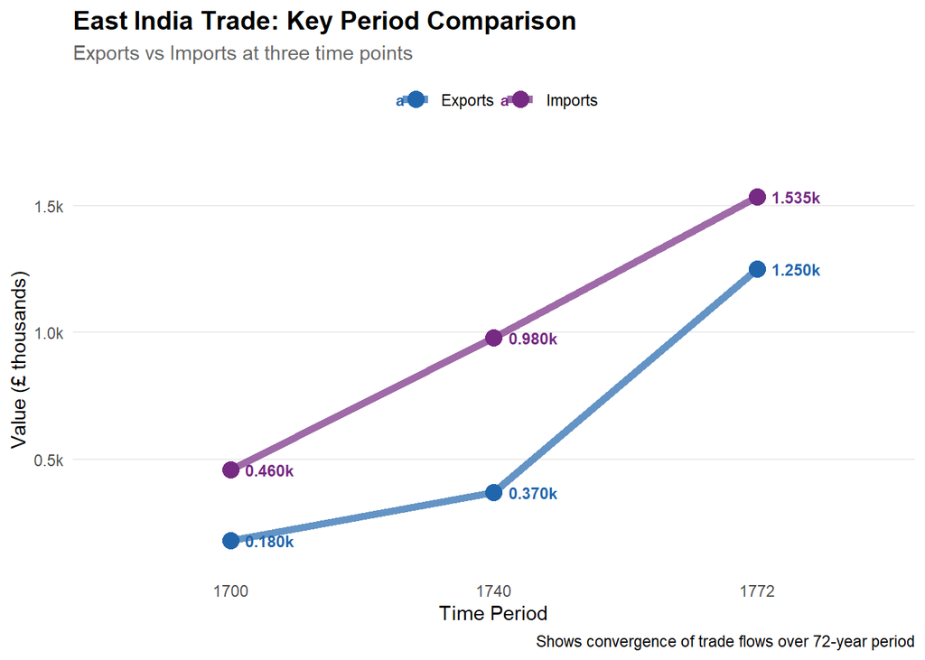

## 3. Minard Data: Modern Campaign Visualizations

[figure not shown]

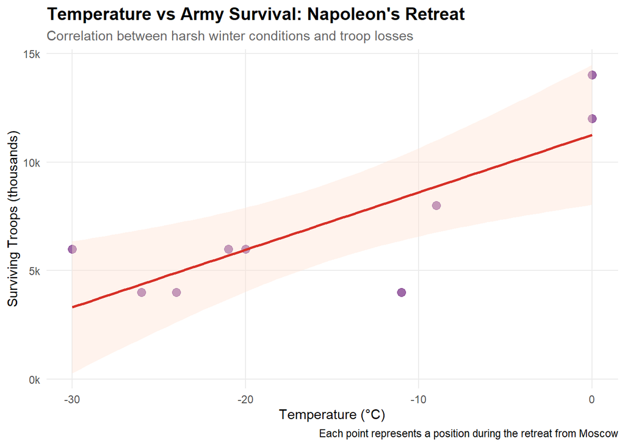

## Summary

### Modern Design Principles Applied

1. **Clear Visual Hierarchy**: Titles, subtitles, and captions guide interpretation
2. **Accessible Color Palettes**: Colorblind-friendly schemes with high contrast
3. **Optimal Data-Ink Ratio**: Minimal non-data ink, clean backgrounds
4. **Direct Encoding**: Straightforward position/length channels vs complex polar/flow mappings
5. **Contextual Annotations**: Text and shading highlight key insights
6. **Consistent Typography**: Professional, readable font choices

### Chart Type Rationale

All modern versions prioritize **cognitive efficiency** and **perceptual accuracy** over aesthetic innovation, following contemporary evidence-based design principles.